# Wizualizacja / wprowadzenie do ggplot2

# Wprowadzenie do pakietu ggplot2

## Przygotowanie danych

Zanim zaczniemy tworzyć pierwszy wykres, musimy przygotować dane do rysowania. Dane można przygotować na wiele sposobów, najprostszym z nich jest użycie pakietu dplyr.

```r
auta2012 = read.table("http://biecek.pl/MOOC/dane/auta2012.csv",
                       sep=";", dec=",", header=TRUE)
head(auta2012, 2)
```

```
##    Cena Waluta Cena.w.PLN Brutto.netto  KM  kW      Marka     Model Wersja
## 1 49900    PLN      49900       brutto 140 103        Kia    Carens
## 2 88000    PLN      88000       brutto 156 115 Mitsubishi Outlander
##   Liczba.drzwi Pojemnosc.skokowa Przebieg.w.km          Rodzaj.paliwa
## 1          4/5              1991         41000 olej napedowy (diesel)
## 2          4/5              2179         46500 olej napedowy (diesel)
##   Rok.produkcji Kolor Kraj.aktualnej.rejestracji Kraj.pochodzenia
## 1          2008                           Polska
## 2          2008                           Polska
##   Pojazd.uszkodzony Skrzynia.biegow Status.pojazdu.sprowadzonego
## 1                          manualna
## 2                          manualna
##                                                                                                                                                                                Wyposazenie.dodatkowe
## 1                         ABS, el. lusterka, klimatyzacja, alufelgi, centralny zamek, autoalarm, poduszka powietrzna, radio / CD, wspomaganie kierownicy, immobiliser, komputer, przyciemniane szyby
## 2 ABS, 4x4, el. lusterka, klimatyzacja, skorzana tapicerka, alufelgi, centralny zamek, poduszka powietrzna, radio / CD, wspomaganie kierownicy, immobiliser, komputer, tempomat, przyciemniane szyby
##   Informacje.dodatkowe
## 1  pierwszy wlasciciel
## 2  pierwszy wlasciciel
```

### Pierwszy wykres

W pakiecie ggplot2 wykresy można tworzyć na dwa sposoby:

- z użyciem funkcji qplot (q like quick), proste wykresy tworzy się prosto, ale bardziej trudniej,
- z użyciem funkcji ggplot(), z początku może nie jest zbyt intuicyjna, ale po pewnym czasie nasza intuicja się zmienia.

Nam zależy nam na profesjonalnej grafice, więc będziemy pracować z funkcją ggplot().

Zaczniemy od wykresy punktowego.

```r
library(ggplot2)
library(dplyr)
wybraneAuta <- auta2012 %>%
          filter(Marka %in% c("Volkswagen", "Opel", "Audi", "Mercedes-Benz", "BMW"))

avgs <- wybraneAuta %>%
          group_by(Marka, Rok.produkcji) %>%
          summarise(cena = median(Cena.w.PLN, na.rm=TRUE),
                    przebieg = median(Przebieg.w.km, na.rm=TRUE),
                    liczba = n()) %>%
          filter(liczba >= 10)
avgs
```

```
## Source: local data frame [128 x 5]
## Groups: Marka
##
##    Marka Rok.produkcji  cena przebieg liczba
## 1   Audi          1987  2516   240000     10
## 2   Audi          1988  2156   225000     10
## 3   Audi          1990  2775   230000     20
## 4   Audi          1991  3900   227325     25
## 5   Audi          1992  4750   227500     59
## 6   Audi          1993  5800   230000     73
## 7   Audi          1994  6200   230000     73
## 8   Audi          1995  7900   218000    153
## 9   Audi          1996  8900   204000    200
## 10  Audi          1997 10249   205500    269
## ..   ...           ...   ...      ...    ...
```

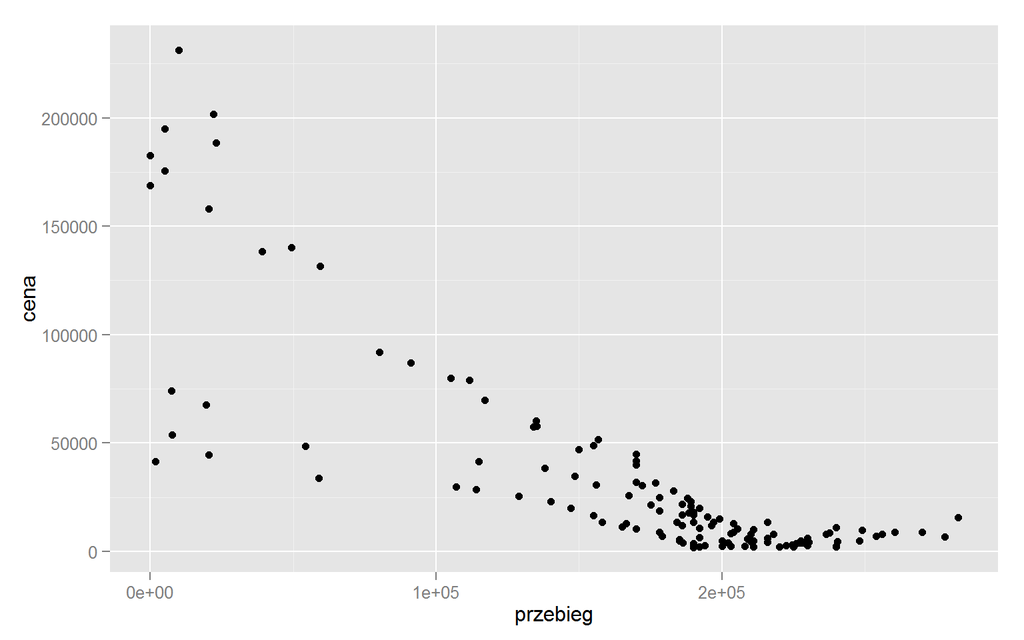

```r
ggplot(avgs, aes(x=przebieg, y=cena)) +
    geom_point()
```

Funkcja ggplot wymaga określenia dwóch argumentów: zbioru danych oraz zbioru mapowań (aesthetic mappings, funkcja aes()). Wybrawszy dane i mapowania można przejść do opisu geometrii.

Grafika produkowana przez pakiet ggplot jest nazywana *‘high quality elegant graphics’* (przynajmniej przez entuzjastów tego pakietu). Zobaczmy dlaczego. Porównajmy dwa wykres z dwóch bibliotek programu R, oba wykresy z domyślnymi ustawieniami. Oba wykresy rysujemy na obszarze 4x4 cale.

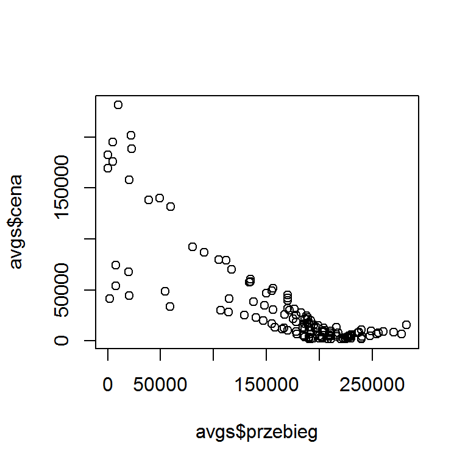

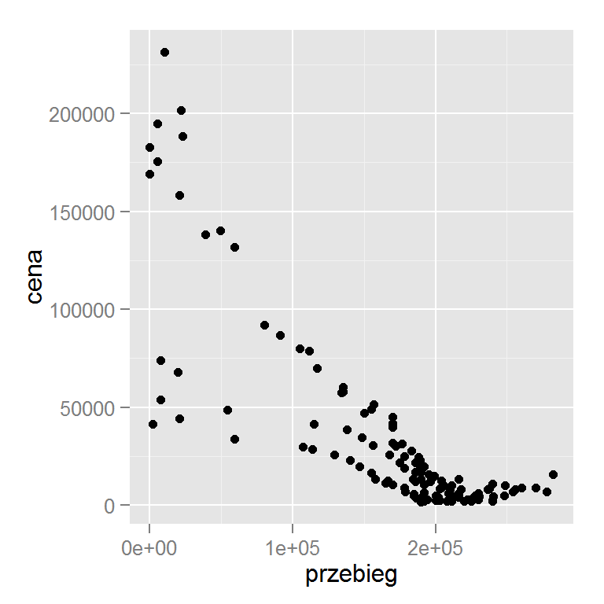

```r
plot(avgs$przebieg, avgs$cena)          # base graphics
ggplot(avgs, aes(x=przebieg, y=cena)) + # ggplot graphics
    geom_point()
```

## Twoja kolej:

Znajd przynajmniej trzy różnice pomiędzy tymi wykresami

## Geometrie

Myśląc o wykresie, w pierwszym kroku myślimy o jego geometrii.

Pakiet ggplot pozwala na wybór spośród wielu geometrii. Ich lista jest dostępna na stronie http://docs.ggplot2.org/current/. Na tych zajęciach będziemy pracować z kilkoma najpopularniejszymi, ale z pozostałych korzysta się w bardzo podobny sposób.

### Dwie ciągłe zmienne

Przyjrzyjmy się na początek trzem geometriom: geom_point(), geom_text(), geom_smooth().

W dokumentacji dla każdej geometrii można zobaczyć jakie właściwości tej geometrii można określić.

Dla geom_text trzy obowiązkowe to x, y i label. http://docs.ggplot2.org/current/geom_text.html.

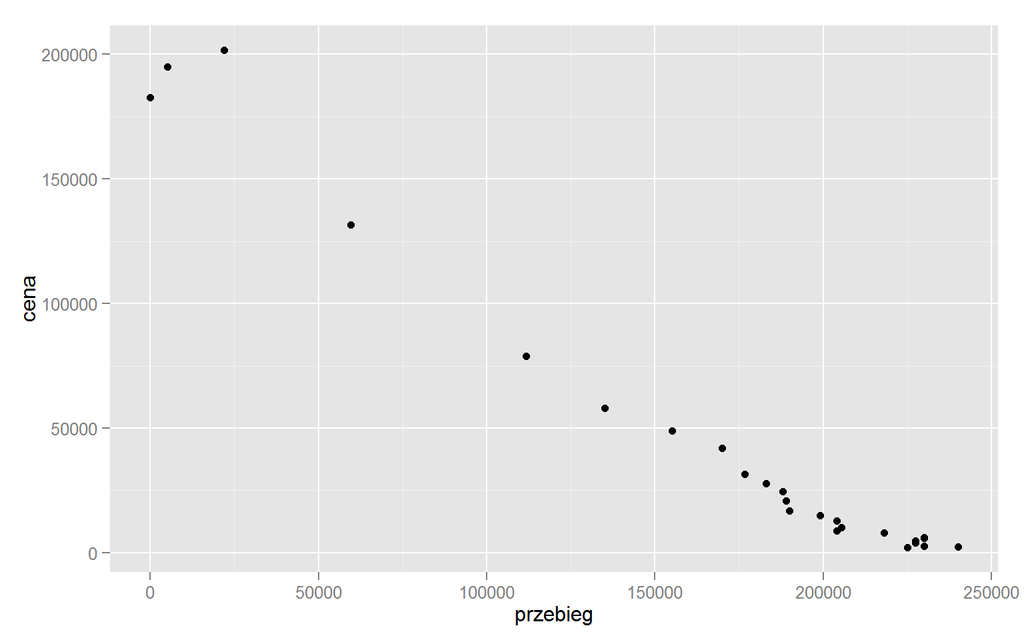

```r
tylkoAudi <- avgs %>%
  filter(Marka == "Audi")

ggplot(tylkoAudi, aes(x=przebieg, y=cena)) +
  geom_point()
```

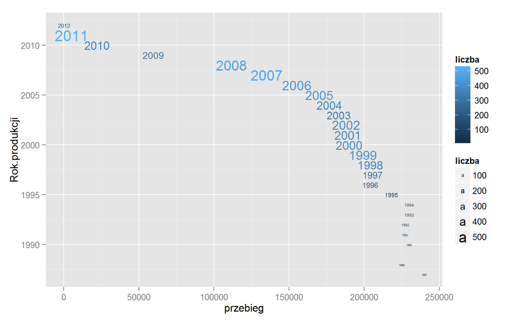

```r
ggplot(tylkoAudi, aes(x=przebieg, y=Rok.produkcji, label=Rok.produkcji, size=liczba, colour=liczba)) +
  geom_text()
```

A co z nieobowiązkowymi mapowaniami? Też mogą być przydatne.

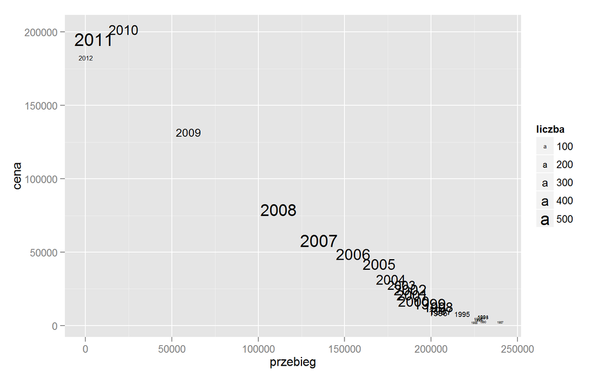

```r
ggplot(tylkoAudi, aes(x=przebieg, y=cena, label=Rok.produkcji)) +
  geom_text(aes(size=liczba))
```

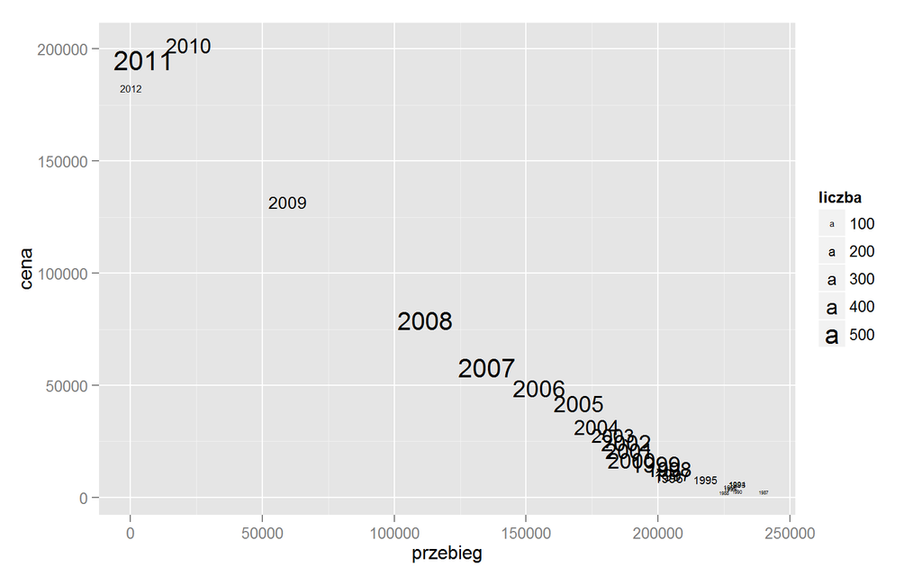

```r
ggplot(tylkoAudi, aes(x=przebieg, y=cena, label=Rok.produkcji)) +
  geom_text(aes(size=liczba))
```

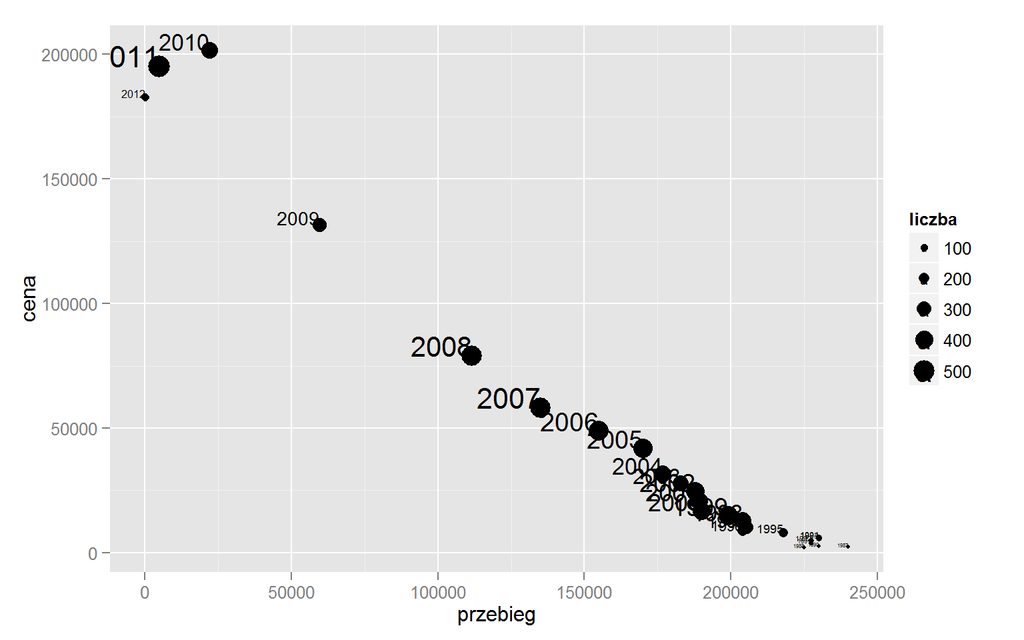

```r
ggplot(tylkoAudi, aes(x=przebieg, y=cena, label=Rok.produkcji, size=liczba)) +
 geom_text(hjust=1, vjust=0) +
  geom_point()
```

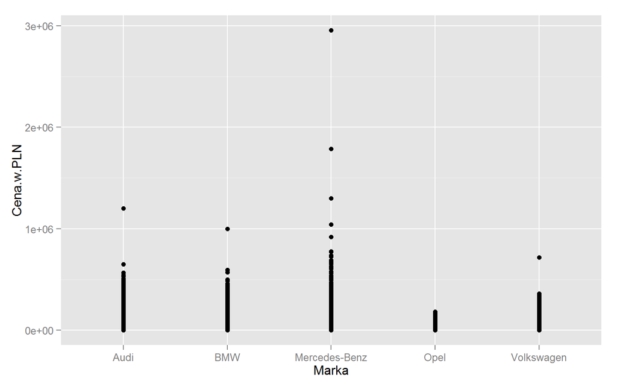

```r
ggplot(wybraneAuta, aes(x=Marka, y=Cena.w.PLN, label=Rok.produkcji)) +
  geom_point()
```

W kolejnych krokach, można dopracowywać szczegóły, np. etykiety na osiach.

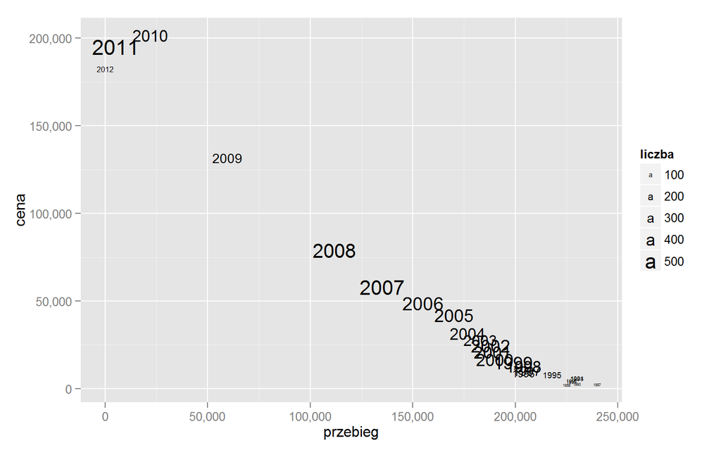

```r
library(scales)
ggplot(tylkoAudi, aes(x=przebieg, y=cena, label=Rok.produkcji)) +
  geom_text(aes(size=liczba)) +
  scale_x_continuous(labels = comma) +
  scale_y_continuous(labels = comma)
```

Uwaga, mapuje się tylko zmienne. Pojedyncze wartości / stałe określa się inaczej.

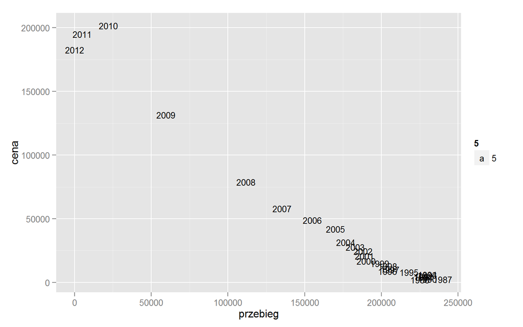

```r
ggplot(tylkoAudi, aes(x=przebieg, y=cena, label=Rok.produkcji)) +
  geom_text(aes(size=5))
```

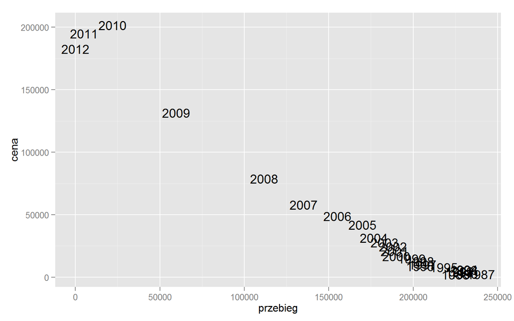

```r
ggplot(tylkoAudi, aes(x=przebieg, y=cena, label=Rok.produkcji)) +
  geom_text(size=5)
```

### geom_smooth()

Pracując ze zmiennymi ciągłymi, szukając zależności typu regresyjnego, jedną z ciekawszych geometrii jest geom_smooth().

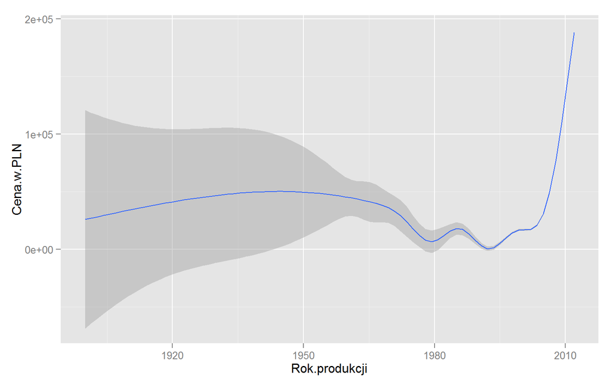

```r
ggplot(wybraneAuta, aes(x=Rok.produkcji, y=Cena.w.PLN)) +
    geom_smooth()
```

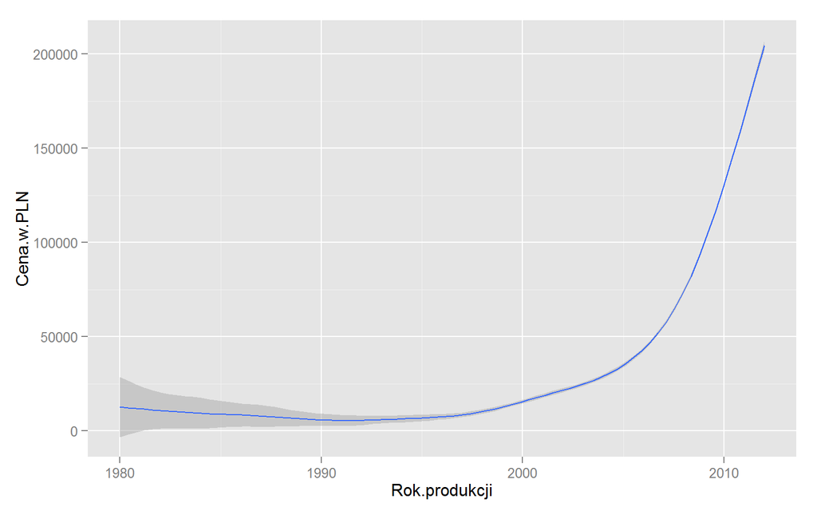

```r
ggplot(wybraneAuta, aes(x=Rok.produkcji, y=Cena.w.PLN)) +
    geom_smooth()  + xlim(1980,2012)
```

Usuniemy teraz przedział ufności dla średniej i dodajmy punkty do wykresu (kolejną geometrię).

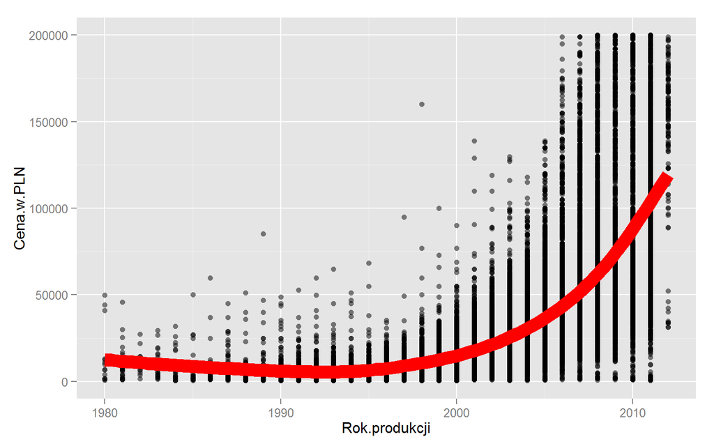

```r
ggplot(wybraneAuta, aes(x=Rok.produkcji, y=Cena.w.PLN)) +
  geom_point(alpha=0.5) +
  geom_smooth(se = FALSE, size=5, colour="red")  +
  xlim(1980,2012) + ylim(0,200000)
```

Zauważmy, że geom_smooth() nie tylko wygładza. Można dodatkowymi parametrami określić jaki model regresyjny ma być przedstawiony na wykresie.

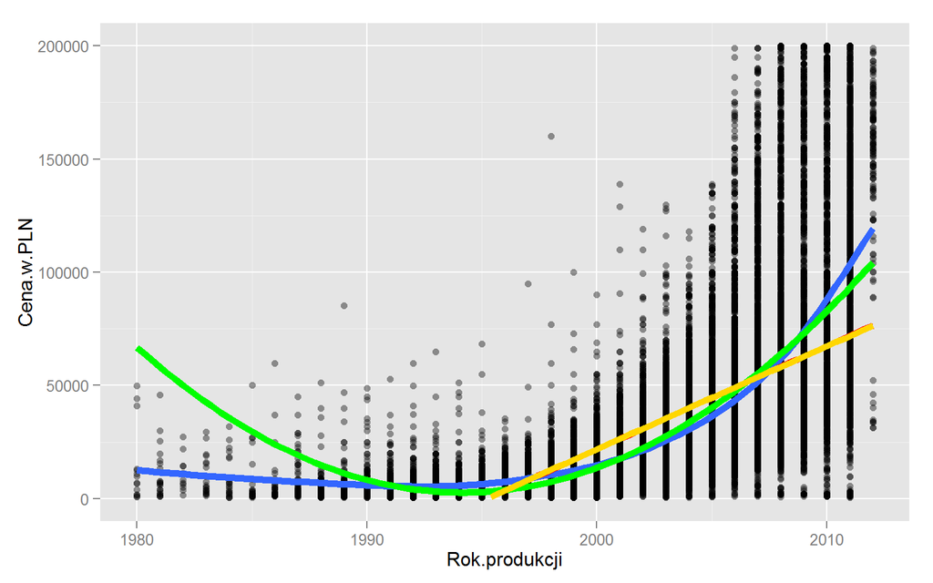

```r
ggplot(wybraneAuta, aes(x=Rok.produkcji, y=Cena.w.PLN)) +
    geom_point(alpha=0.4) +
    geom_smooth(se = FALSE, size=2) +
    geom_smooth(se = FALSE, size=2, method = "lm", colour="red") +
    geom_smooth(se = FALSE, size=2, method = "lm", colour="green", formula = y ~ poly(x,2)) +
    geom_smooth(se = FALSE, size=2, method = "lm", colour="gold", formula = y ~ log(x)) +
  xlim(1980,2012) + ylim(0,200000)
```

Zmieniamy stopień wygładzenia.

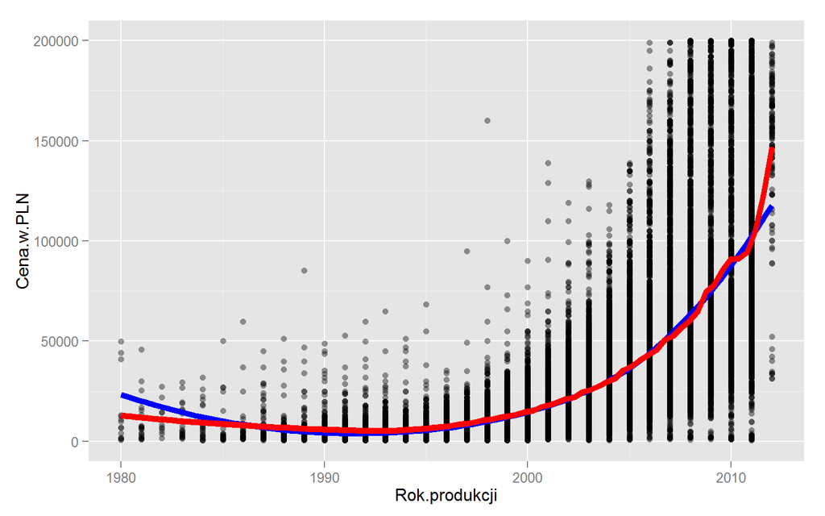

```r
ggplot(wybraneAuta, aes(x=Rok.produkcji, y=Cena.w.PLN)) +
    geom_point(alpha=0.4) +
    geom_smooth(se = FALSE, size=2, colour="blue", span=0.9, method="loess") +
    geom_smooth(se = FALSE, size=2, colour="red", span=0.1, method="loess") +
  xlim(1980,2012) + ylim(0,200000)
```

Składając różne mapowania i geometrie można uzyskać bardzo ciekawe rozwiązania

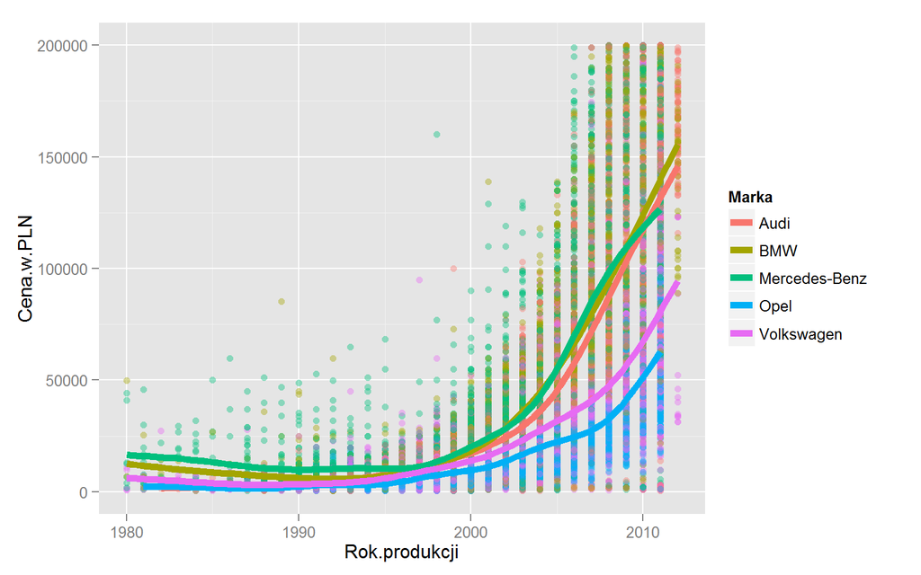

```r
ggplot(wybraneAuta, aes(x=Rok.produkcji, y=Cena.w.PLN, colour=Marka)) +
    geom_point(alpha=0.4) +
    geom_smooth(se = FALSE, size=2) +
  xlim(1980,2012) + ylim(0,200000)
```

### Dla zmiennych jakościowych

Wykresy paskowe i ich odmiany są wygodne w przedstawianiu zmiennych jakościowych. Jako przykład wykorzystamy geom_bar().

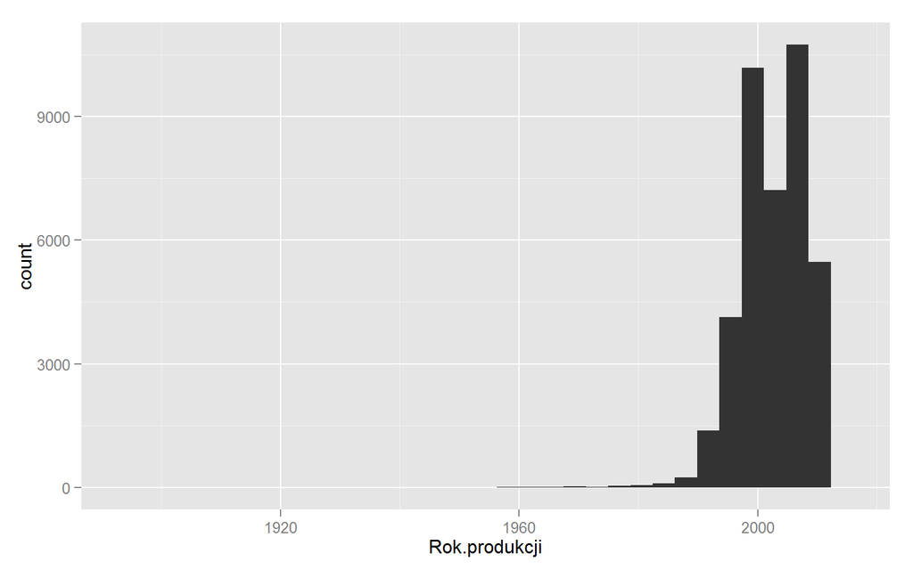

```r
ggplot(wybraneAuta, aes(x=Rok.produkcji)) +
  geom_bar()
```

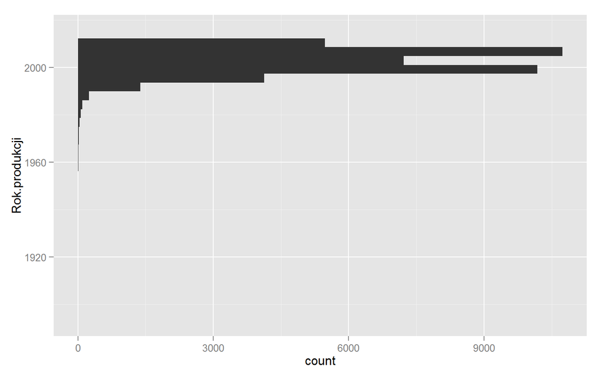

```r
# horizontal or vertical?
ggplot(wybraneAuta, aes(x=Rok.produkcji)) +
  geom_bar() +
  coord_flip()
```

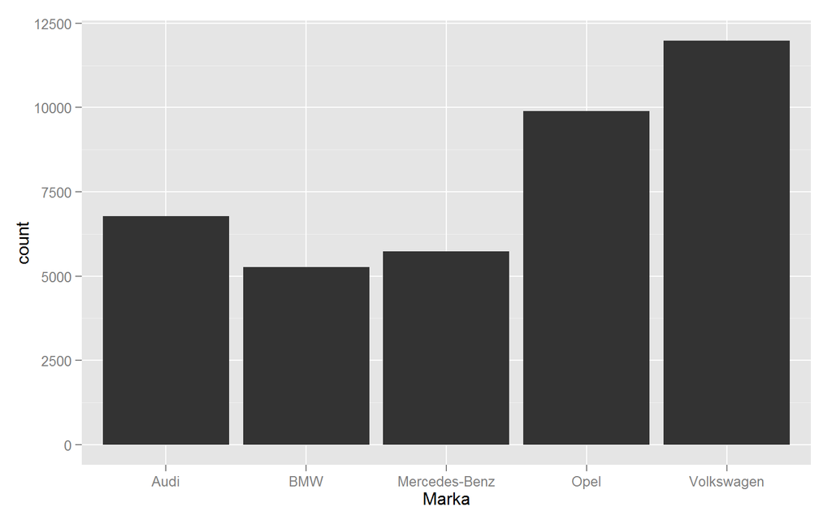

```r
ggplot(wybraneAuta, aes(x=Marka)) +
  geom_bar()
```

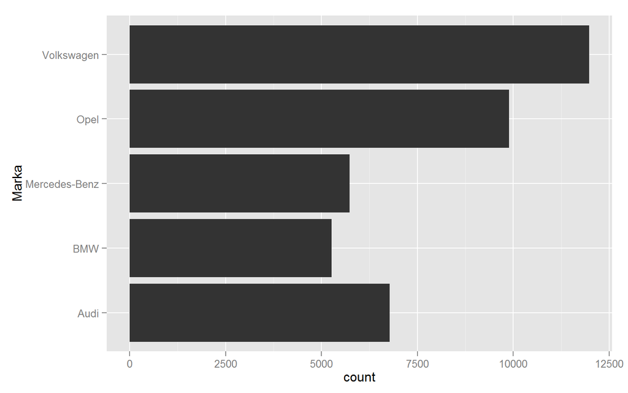

```r
# horizontal or vertical?
ggplot(wybraneAuta, aes(x=Marka)) +
  geom_bar() +
  coord_flip()
```

Zobacz jakie parametry geometrii geom_bar() można modyfikować http://docs.ggplot2.org/current/geom_bar.html.

Jednym z takich parametrów jest ‘position’.

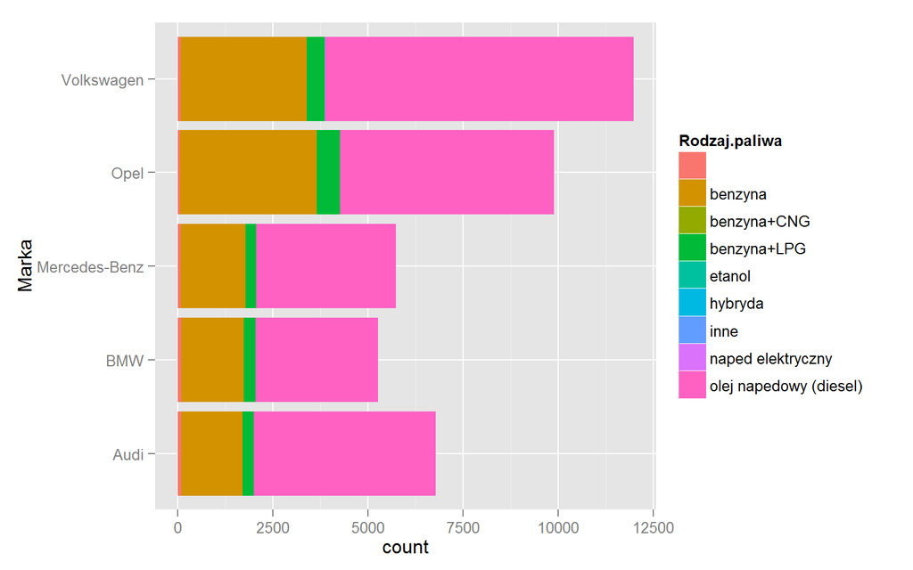

```r
ggplot(wybraneAuta, aes(x=Marka, fill=Rodzaj.paliwa)) +
    geom_bar() + coord_flip()
```

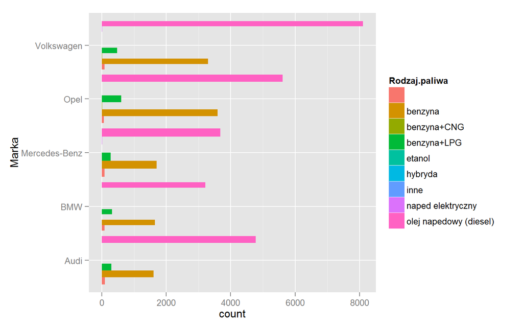

```r
# Position = dodge
ggplot(wybraneAuta, aes(x=Marka, fill=Rodzaj.paliwa)) +
    geom_bar(position="dodge") + coord_flip()
```

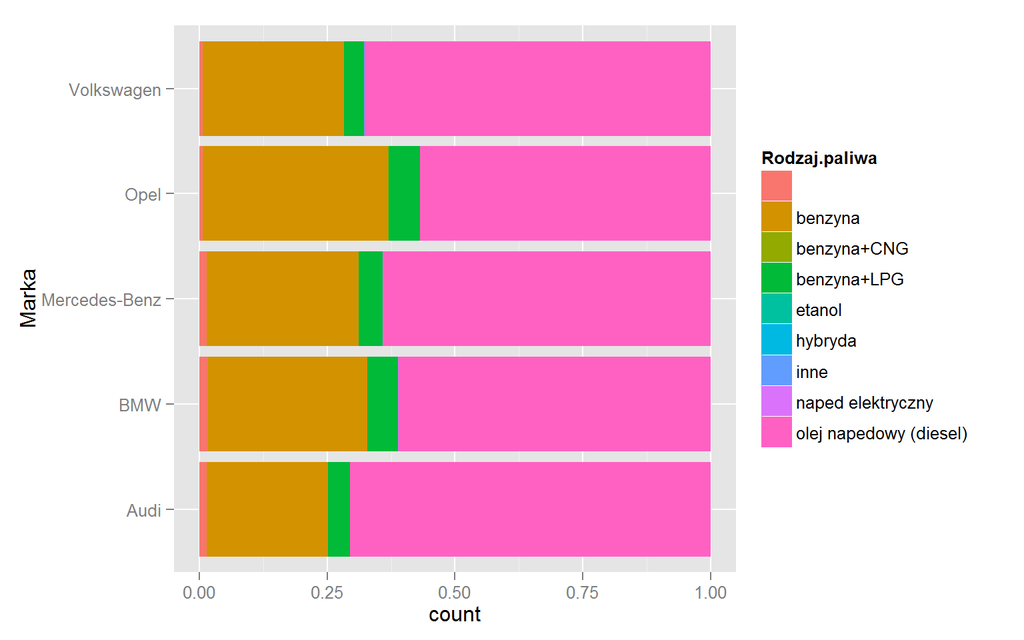

```r
# Position = fill
ggplot(wybraneAuta, aes(x=Marka, fill=Rodzaj.paliwa)) +
    geom_bar(position="fill") + coord_flip()
```

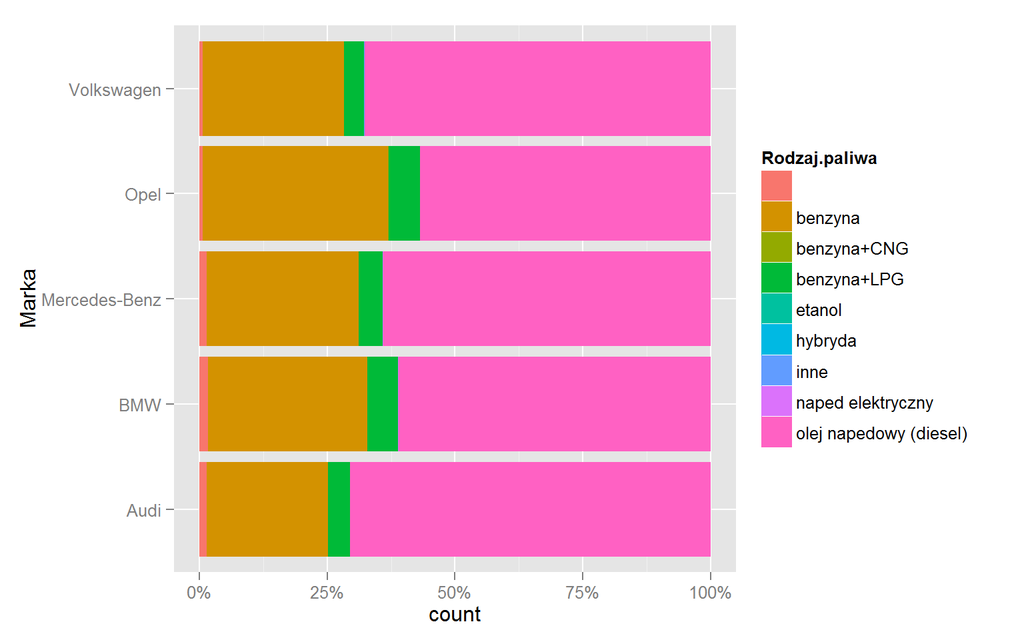

```r
# Procenty na osi OX
ggplot(wybraneAuta, aes(x=Marka, fill=Rodzaj.paliwa)) +
    geom_bar(position="fill") + coord_flip() +
    scale_y_continuous(label=percent)
```

### Inne geometrie

Liczba geometrii dostępnych w pakiecie ggplot2 się zmienia. Czasem przybywają nowe, nadmiarowe geometrie mogą zostać zredukowane. W dodatkowych pakietach można również znaleźć nowe geometrie.

Aby sprawdzić jaka jest aktualna lista geometrii najlepiej odwiedzić stronę http://docs.ggplot2.org/current/.

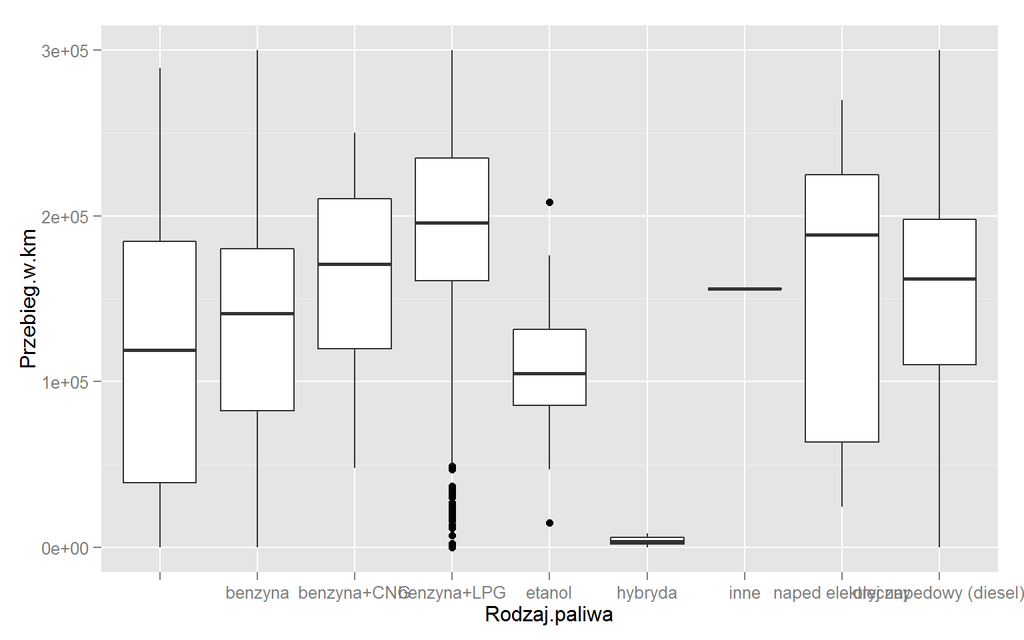

```r
ggplot(wybraneAuta, aes(y=Przebieg.w.km, x=Rodzaj.paliwa)) +
  geom_boxplot() + ylim(0,300000)
```

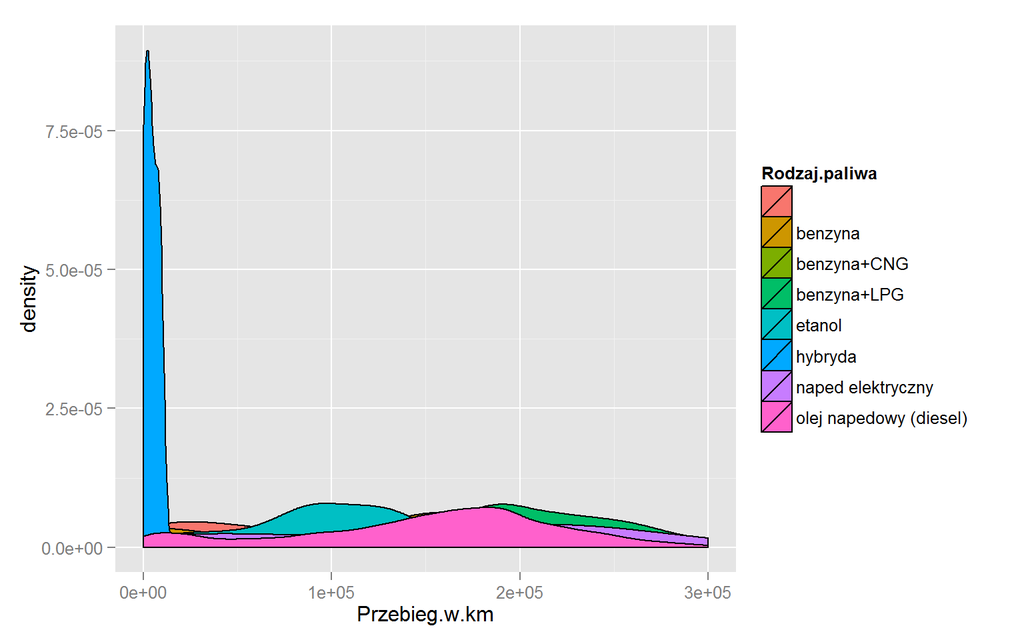

```r
ggplot(wybraneAuta, aes(x=Przebieg.w.km, fill=Rodzaj.paliwa)) +
  geom_density() + xlim(0,300000)
```

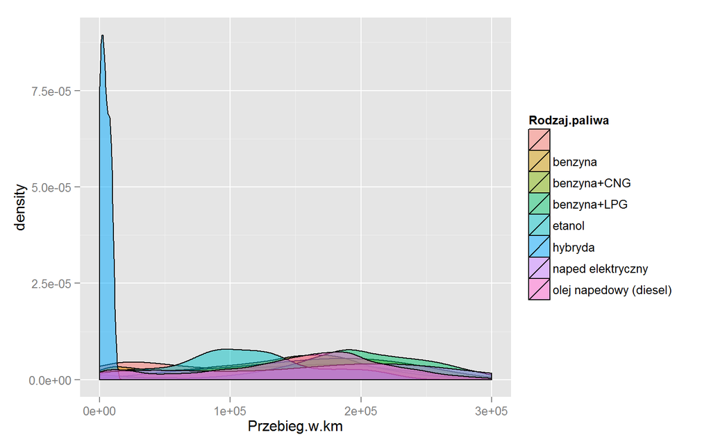

```r
ggplot(wybraneAuta, aes(x=Przebieg.w.km, fill=Rodzaj.paliwa)) +
  geom_density(alpha=0.5) + xlim(0,300000)
```

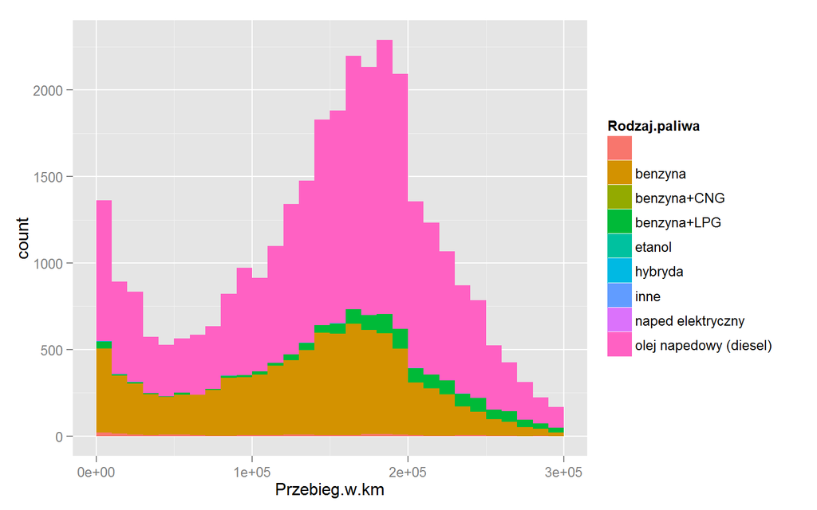

```r
ggplot(wybraneAuta, aes(x=Przebieg.w.km, fill=Rodzaj.paliwa)) +
  geom_histogram() + xlim(0,300000)
```

## Inne źródła

- bardzo dobra książka ‘Cookbook for R’, http://www.cookbook-r.com/Graphs/
- dokumentacja pakietu ggplot2, http://docs.ggplot2.org/current/
- webinaria ‘The Grammar and Graphics of Data Science’ http://pages.rstudio.net/Webniar-Series-Essential-Tools-for-R.html
- Introduction to dplyr http://cran.rstudio.com/web/packages/dplyr/vignettes/introduction.html